# Predicting Diamond Price: Regression Modeling Practice

R. A. Reitmeyer  
2017-03-05

### Predicting Diamond Price: Regression Modeling Practice

The author is pleased to announce a R Shiny application students of the Coursera “Data Science” lectures can use to practice their regression skills: [http://rareitmeyer.shinyapps.io/data_products_diamonds/]

Predicting Diamond Price: Regression Modeling Practice is now available on Rpubs.

This app helps students focus on regression modeling, using the ggplot2 “diamonds” data set.

The github source for this app is available online at [http://github.com/rareitmeyer/data_products_diamonds/]

### Prediction skills need practice

Like any other skill, prediction is something aspiring data science students need to practice to get better at.

The app has built-in exploratory data analysis, and automatically breaks data into test and training sets.

Regression models are automatically evaluated on the test set. In addition to the standard root mean squared error (RMSE), a small table is provided with a six number summary of errors.

Last but hardly least, the residualPlots from the car package are automatically generated, to help the student quickly spot trends in the training set errors.

### Test Errors

The app calculates out-of-sample errors, and shows students a small summary table. For a simple model of price ~ caret + color:

```r
mdl <- lm(price~carat+color, diamonds_train)
print_xtable(testErrors(mdl, diamonds_test))
```

| metric | value |
| --- | --- |
| min error | 0.21 |
| 25th percentile error | 288.64 |
| median error | 642.50 |
| average error | 968.13 |
| 75th percentile error | 1209.16 |
| max error | 12593.91 |
| RMSE | 1480.63 |

### Diagnostics

Here's a typical diagnostic graph for a simple price ~ carat + color model. Note the graph shows nolinear behavior with carat, suggesting adding a carat<sup>2</sup> term is appropriate:

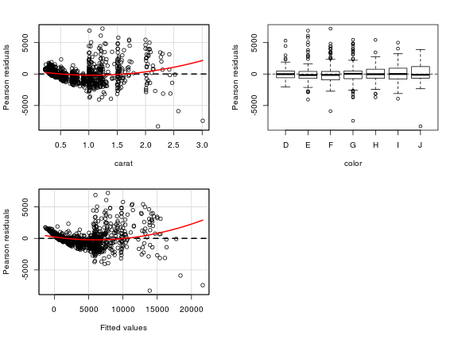